# R project - cleaning summary

Jigar Patel

08/12/2021

## Data Cleaning

This part consists of cleaning 3 CSVs.

- `tdf_Stages`
- `stage_date`
- `tdf_winners`

We will go through each of the files and see what columns they consist and what type of data it has.

### `tdf_stages`

There are many columns with different data types. First we will check if there are any null values. After viewing the data, we see that there are no null values, and also the data points seem to be consistent and not vaguely different. Hence cleaning this file is not necessary.

### `stage_data`

#### Checking the null values in the `stage_data`

```
##   edition year stage_results_id rank time rider  age  team points elapsed
## 1       0    0                0    0 5617     0 3326 17159 222746    5617
##   bib_number
## 1      23534
```

There are many columns with many null values. We will go through each of the columns and see how we deal with null values.

#### `stage_data$time` and `stage_data$elapsed`

Initial data type = `character` string

Histogram plot (`stage_data$time`) and (`stage_data$elapsed`)

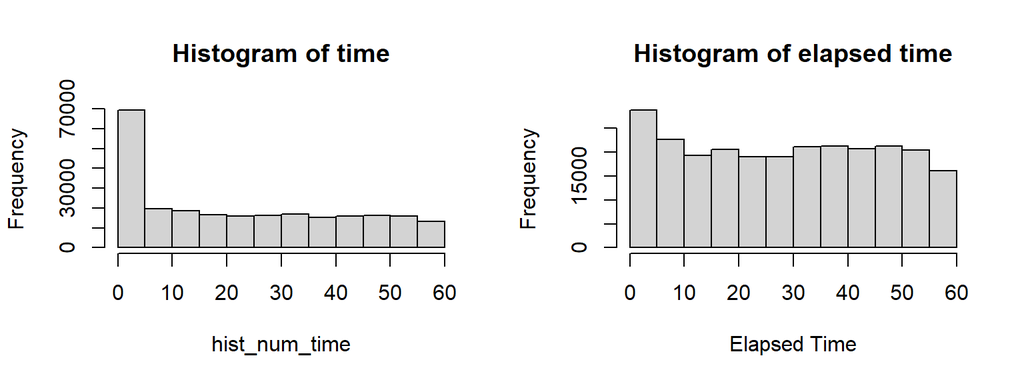

$time \sim Unif(a=0,b=60)$

$\text{elapsed time} \sim Unif(a=0,b=60)$

The peak at 0 seems to be an error. We replace the null values with a uniform distribution from 0 to 60,

#### `stage_data$age`

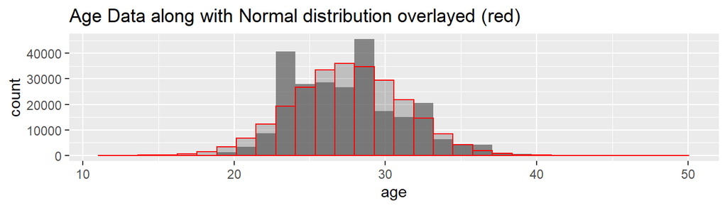

$N(\mu_{age}, \sigma_{age}) \sim \text{Age Data}$

Null-values replaced by above distribution.

#### `stage_data$team`

`NA` or `""` $\implies$ *“No Team”*

Replaced the *empty characters* and *null-values* with *“No Team”*.

#### `stage_data$points`

Removing the column due to number of null values.

#### `stage_data$bib_number`

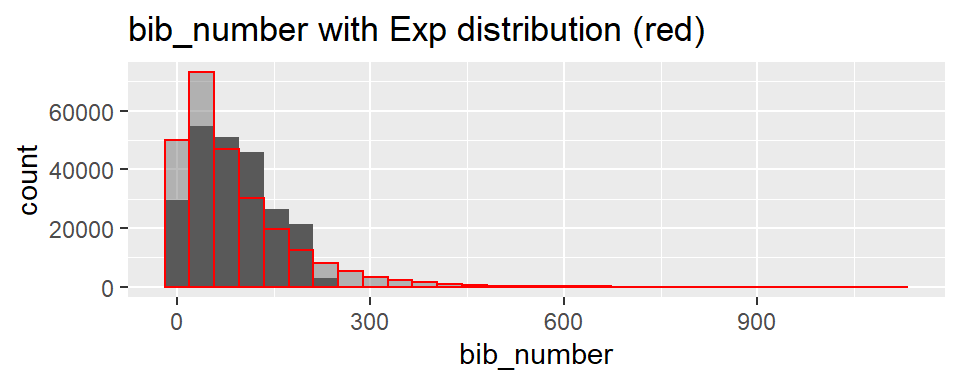

bib_number $\sim Exp(rate=\dfrac{1}{\mu_{\text{bib_number}}})$

Replacing *null-values* with the values following the above distribution.

```
##   edition year stage_results_id rank time rider age team elapsed bib_number
## 1       0    0                0    0    0     0   0    0       0          0
```

### `tdf_winners`

Columns consisting of null values:

```
##   edition start_date winner_name winner_team distance time_overall time_margin
## 1       0          0           0           0        0            8           8
##   stage_wins stages_led height weight age born died full_name nickname
## 1          0          0     40     39   0    0   50        60       32
##   birth_town birth_country nationality
## 1          0             0           0
```

#### `tdf_winners$height` & `tdf_winners$weight`

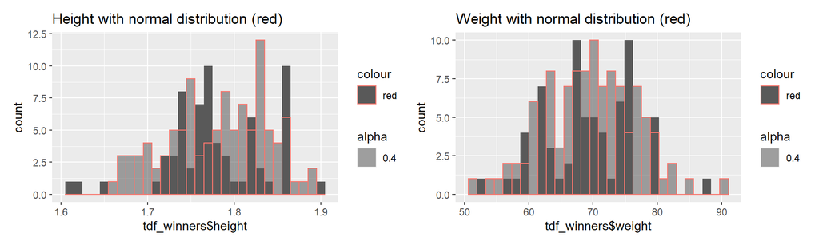

Height, Weight $\sim N(\mu_{Height,Weight},\sigma_{Height,Weight})$

Replaced null values with the normally distributed random variables with height’s and weight’s $\mu$s and $\sigma$s.

#### Removing `nickname`,`full_name`,`died` columns as they are not useful for analysis.

#### `tdf_winners$time_overall` & `tdf_winners$time_margin`

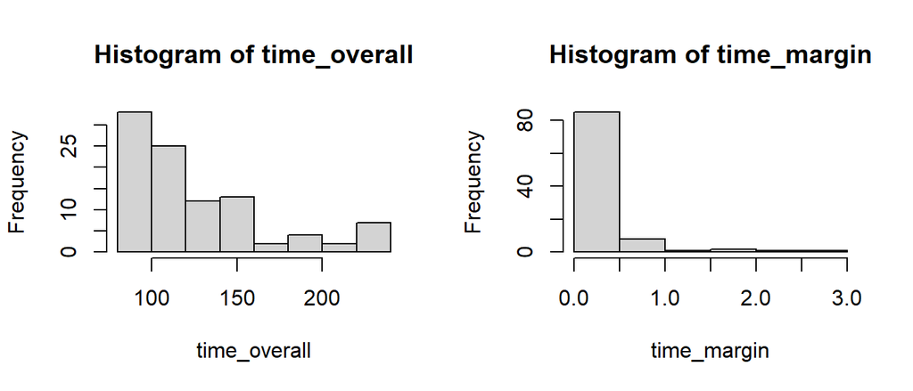

Substituting *null-values* with exponentially distributed random variables since they both approximately follow exponential distributions.

All three data-sets now have no-null values.

Adding new columns will be included in the *Analysis section* for calculating and analyzing new information.